# R Notebook

# Problem

our dataset contains information on patients, including their age, gender, various test results, and whether they have liver disease or not. The problem is to develop a model that can accurately predict the presence of liver disease based on these clinical features. Early detection of liver disease is crucial for effective treatment and management. By accurately predicting the disease, healthcare professionals can intervene timely and provide appropriate medical care, leading to improved patient outcomes and efficient allocation of resources.

# Data Mining Task

The dataset requires data mining tasks of classification and clustering.

Classification involves predicting whether a patient has a liver disease or not based on the class label “dataset”, indicates (1 diseases or 2 no diseases ). The goal is to develop an accurate model for classifying new patients into disease categories.

Clustering aims to identify natural groupings or patterns within the data. By analyzing attribute similarities, clusters can be discovered.

# Data

link to the source of our dataset: {https://www.kaggle.com/uciml/indian-liver-patient-records}

general info about the dataset:

Number of attributes: 11

age (numeric) gender (symmetric binary) Total_Bilirubin (numeric) direct_Bilirubin (numeric) Alkaline_Phosphotase (numeric) Alamine_Aminotransferase (numeric) Aspartate_Aminotransferase (numeric) Total_Protiens (numeric) Albumin (numeric) Albumin_and_Globulin_Ratio (numeric) Dataset (asymmetric binary)

Number of objects: 583 objects

class label :(dataset) which indicates (1 disease or 2 no disease)

### Importing the dataset

read file named “indian_liver_patient” and save it in dataframe named “dataset”

```r
dataset = read.csv("C:\\Users\\User\\Desktop\\dataMining\\indian_liver_patient (1).csv")
```

### raw data and summary of the dataset

```r
View(dataset)
str(dataset)
```

```
## 'data.frame':    583 obs. of  11 variables:
##  $ Age                       : int  65 62 62 58 72 46 26 29 17 55 ...
##  $ Gender                    : chr  "Female" "Male" "Male" "Male" ...
##  $ Total_Bilirubin           : num  0.7 10.9 7.3 1 3.9 1.8 0.9 0.9 0.9 0.7 ...
##  $ Direct_Bilirubin          : num  0.1 5.5 4.1 0.4 2 0.7 0.2 0.3 0.3 0.2 ...
##  $ Alkaline_Phosphotase      : int  187 699 490 182 195 208 154 202 202 290 ...
##  $ Alamine_Aminotransferase  : int  16 64 60 14 27 19 16 14 22 53 ...
##  $ Aspartate_Aminotransferase: int  18 100 68 20 59 14 12 11 19 58 ...
##  $ Total_Protiens            : num  6.8 7.5 7 6.8 7.3 7.6 7 6.7 7.4 6.8 ...
##  $ Albumin                   : num  3.3 3.2 3.3 3.4 2.4 4.4 3.5 3.6 4.1 3.4 ...
##  $ Albumin_and_Globulin_Ratio: num  0.9 0.74 0.89 1 0.4 1.3 1 1.1 1.2 1 ...
##  $ Dataset                   : int  1 1 1 1 1 1 1 1 2 1 ...
```

```r
summary(dataset)
```

```
##       Age           Gender          Total_Bilirubin  Direct_Bilirubin
##  Min.   : 4.00   Length:583         Min.   : 0.400   Min.   : 0.100
##  1st Qu.:33.00   Class :character   1st Qu.: 0.800   1st Qu.: 0.200
##  Median :45.00   Mode  :character   Median : 1.000   Median : 0.300
##  Mean   :44.75                      Mean   : 3.299   Mean   : 1.486
##  3rd Qu.:58.00                      3rd Qu.: 2.600   3rd Qu.: 1.300
##  Max.   :90.00                      Max.   :75.000   Max.   :19.700
##
##  Alkaline_Phosphotase Alamine_Aminotransferase Aspartate_Aminotransferase
##  Min.   :  63.0       Min.   :  10.00          Min.   :  10.0
##  1st Qu.: 175.5       1st Qu.:  23.00          1st Qu.:  25.0
##  Median : 208.0       Median :  35.00          Median :  42.0
##  Mean   : 290.6       Mean   :  80.71          Mean   : 109.9
##  3rd Qu.: 298.0       3rd Qu.:  60.50          3rd Qu.:  87.0
##  Max.   :2110.0       Max.   :2000.00          Max.   :4929.0
##
##  Total_Protiens     Albumin      Albumin_and_Globulin_Ratio    Dataset
##  Min.   :2.700   Min.   :0.900   Min.   :0.3000             Min.   :1.000
##  1st Qu.:5.800   1st Qu.:2.600   1st Qu.:0.7000             1st Qu.:1.000
##  Median :6.600   Median :3.100   Median :0.9300             Median :1.000
##  Mean   :6.483   Mean   :3.142   Mean   :0.9471             Mean   :1.286
##  3rd Qu.:7.200   3rd Qu.:3.800   3rd Qu.:1.1000             3rd Qu.:2.000
##  Max.   :9.600   Max.   :5.500   Max.   :2.8000             Max.   :2.000
##                                  NA's   :4
```

as shown in the result, we have 4 null values in Albumin_and_Globulin_Ratio column we can also see there are some values are quite distant from the 3rd Qu values, in Alamine_Aminotransferase the max value is 2000 but the 3rd Qu is 60.5, Also in Alkaline_Phosphotase the max is 2110 but the 3rd Qu is 298 this scenario is repeating with many attributes which raises the question of whether or not we have outliers in the Dataset.

the range for the age attribute is quite interesting, since the min value is 4 and the max value is 90. the age 4 is quite young which is really concerning considering how dangerous the disease is. we will show more information about all the attributes through the boxplots.

## Dealing with the missing values

as shown previously we had 4 null values in Albumin_and_Globulin_Ratio column, as they can bias the results thus, we decided its best to replace them with the mean value of the column, since deleting those tuples means we will be missing out on some valuable data.

```r
dataset$Albumin_and_Globulin_Ratio = ifelse(is.na(dataset$Albumin_and_Globulin_Ratio), ave(dataset$Albumin_and_Globulin_Ratio, FUN =function(x) mean(x,na.rm=TRUE)), dataset$Albumin_and_Globulin_Ratio)
sum(is.na(dataset))
```

```
## [1] 0
```

```r
summary(dataset$Albumin_and_Globulin_Ratio)
```

```
##    Min. 1st Qu.  Median    Mean 3rd Qu.    Max.
##  0.3000  0.7000  0.9471  0.9471  1.1000  2.8000
```

good, now the null values are replaced with the mean value and to make sure we checked if the Dataset has any null values and the result is 0 which means there is none.

## Box plot for Age

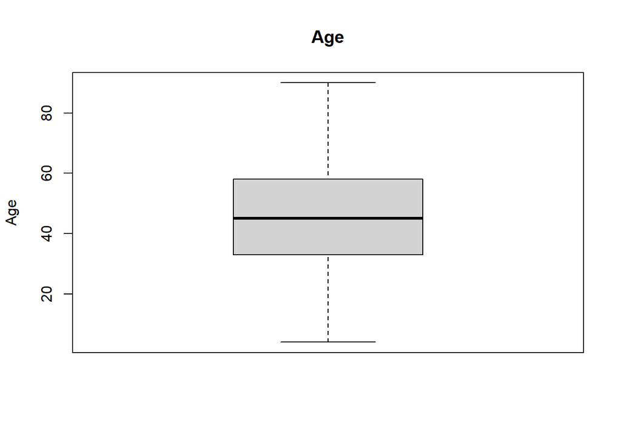

```r
boxplot(dataset$Age, main = "Age", ylab = "Age")
```

the box plot shows no outliers and we can tell that the 1st Qu is at around 33 and the 3rd Qu is at 58, the range is between 4(min) and 90(max) and the median is at around 45. yet again the young ages are really concerning, but the median seems quite normal.

## Box plot for Total Bilirubin

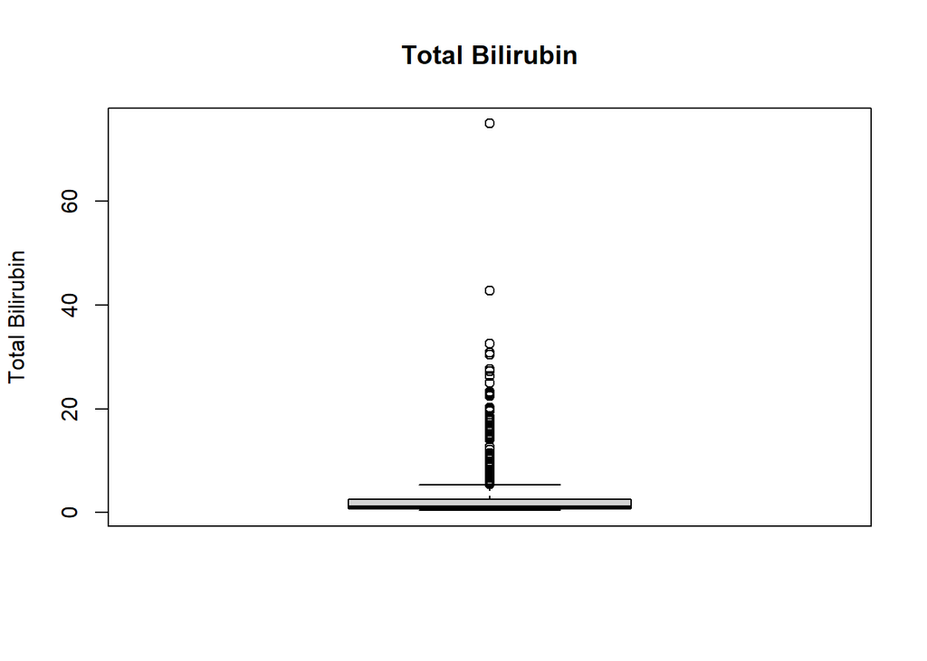

```r
boxplot(dataset$Total_Bilirubin, main = "Total Bilirubin", ylab = "Total Bilirubin")
```

the boxplot shows many outliers above the max value, lets investigate. the min value is 0.4 and the max is 75 (range between 0.4 - 75) the 3rd Qu is at 2.6, there is a big shift between the 3rd Qu and the max, but many values are between 2.6 and 38 which means these are not true outliers rather the boxplot showed them to be so, even the value 75 is quite distant, The range between the 3rd Qu and 38 (where many values are gathering) is quite big which indicates the range would be large.

## Box plot for Direct Bilirubin

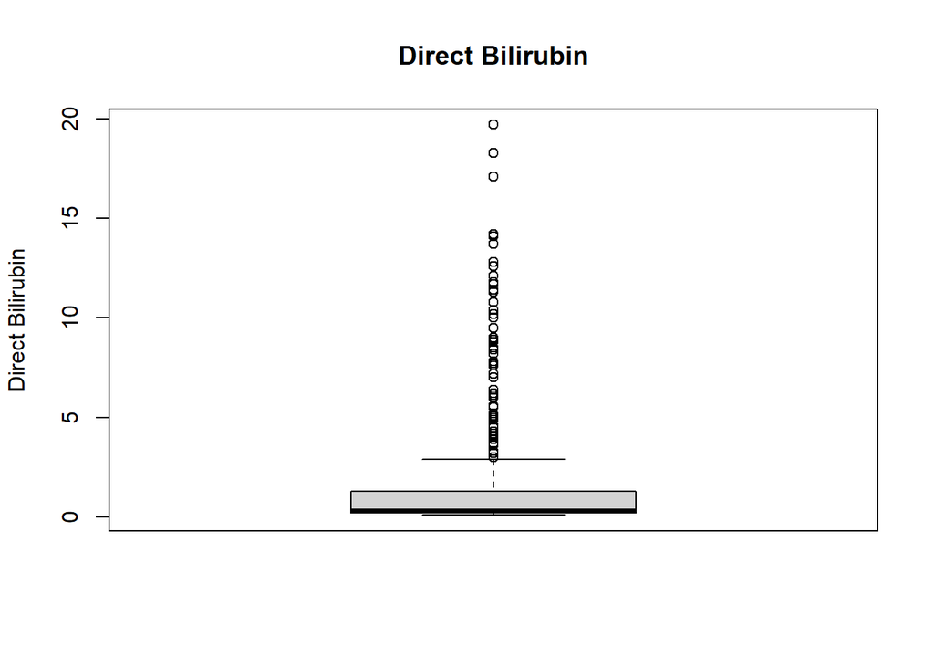

```r
boxplot(dataset$Direct_Bilirubin, main = "Direct Bilirubin", ylab = "Direct Bilirubin")
```

Again we could see from the boxplot there are many outliers, so the min value is 0.1 and the max is 19.7 (range between 0.1 - 19.7)the median is 0.3 and the 3rd Qu is 1.3, we can see a big gap between the 3rd Qu and the max value but there are many values that are gathering between 1.3 and 12 which indactes these are not true outliers since they are so redundant this also means the rest of the outliers are not true either since they are close to 12, again the box plot mistakenly considered them to be outliers.

## Box plot for Alkaline Phosphotase

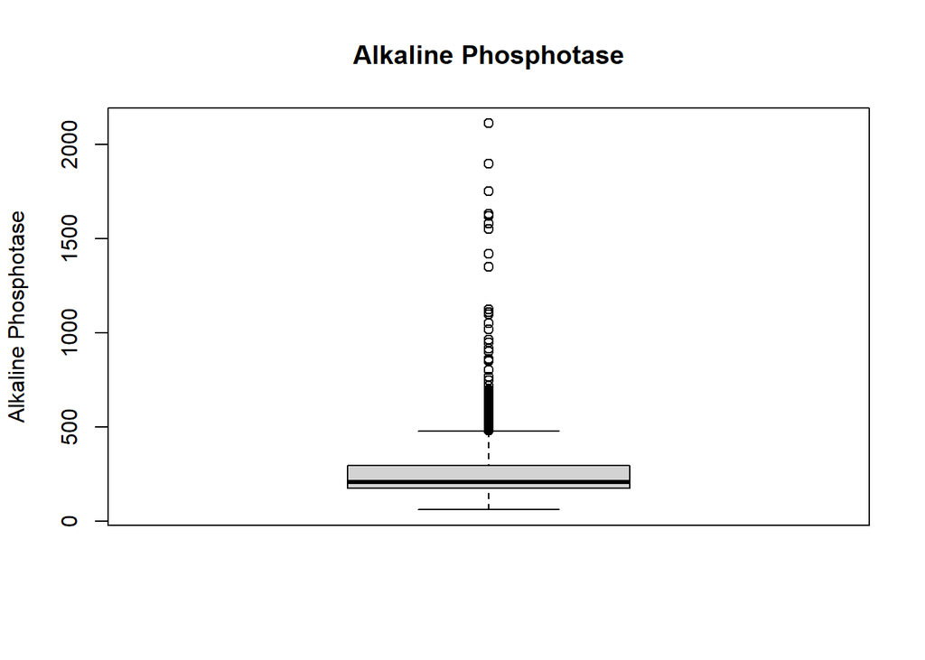

```r
boxplot(dataset$Alkaline_Phosphotase, main = "Alkaline Phosphotase", ylab = "Alkaline Phosphotase")
```

the boxplot shows many outliers gathering between 500 and 1500, the min is 63 and the max is 2110 (range between 63 - 2110) and the median is 208 the 3rd Qu is 298, there is a big shift between the 3rd Qu and the max. yet again since there are many high values it means these are not true outliers.

## Box plot for Alamine Aminotransferase

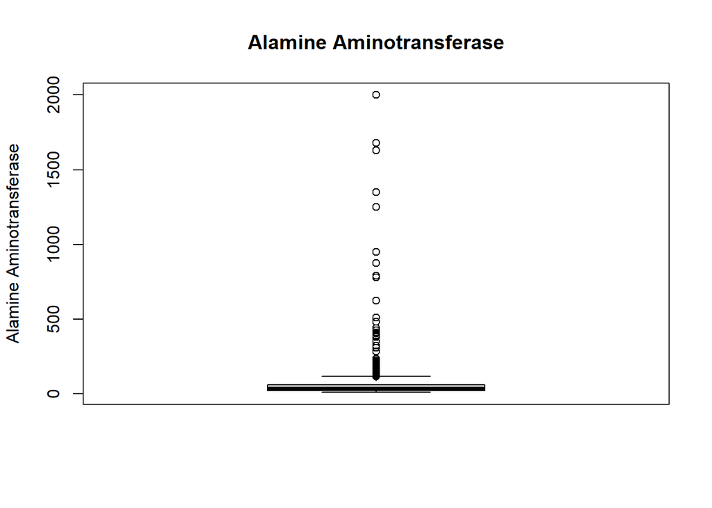

```r
boxplot(dataset$Alamine_Aminotransferase, main = "Alamine Aminotransferase", ylab = "Alamine Aminotransferase")
```

this boxplot is slightly diffirent since the gathering is concentrated alomst under 600 but there is a small gathering above them, for the min value we have 10, max 2000 (range between 10 - 2000) median 35 and 3rd Qu 60, again we can see a big shift but the range is big hence why the boxplot considered many values to be outliers.

## Box plot for Aspartate Aminotransferase

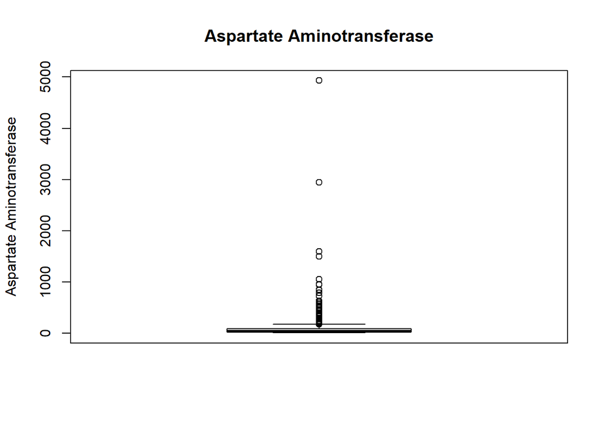

```r
boxplot(dataset$Aspartate_Aminotransferase, main = "Aspartate Aminotransferase", ylab = "Aspartate Aminotransferase")
```

this boxplot shows the gathering stops at almost 1000 but we have few values that are reaching 5000, the max is 4929 and the min is 10 (range between 10 - 4929), the median 42 and the 3rd Qu 87. there is no doubt that the values under 2000 are not outliers, values higher than that are also near to them hence we will not be considering them to be outliers.

## Box plot for Total Protiens

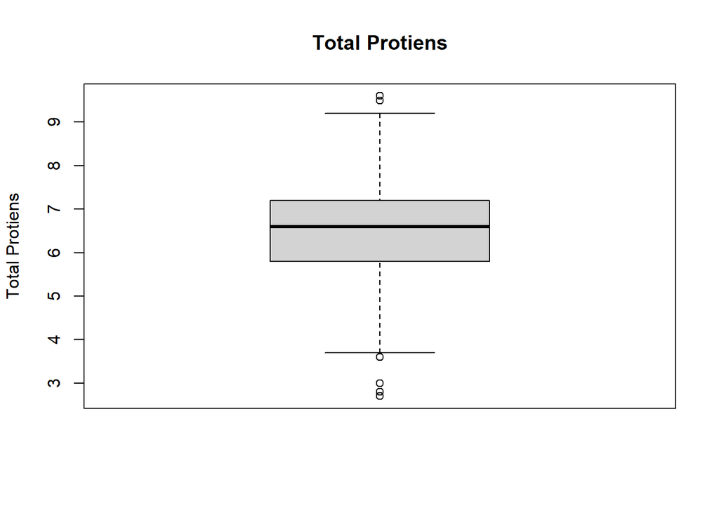

```r
boxplot(dataset$Total_Protiens, main = "Total Protiens", ylab = "Total Protiens")
```

the boxplot shows some outliers above the max and under the min values, the min is 2.7 and the max is 9.6 (range between 2.7 - 9.6), the 1st Qu is 5.8 and the 3rd Qu is 7.2, the median is 6.6, by observing the values the outliers shown on the boxplot are definitley are not true outliers since they are so close to each other.

## Box plot for Albumin

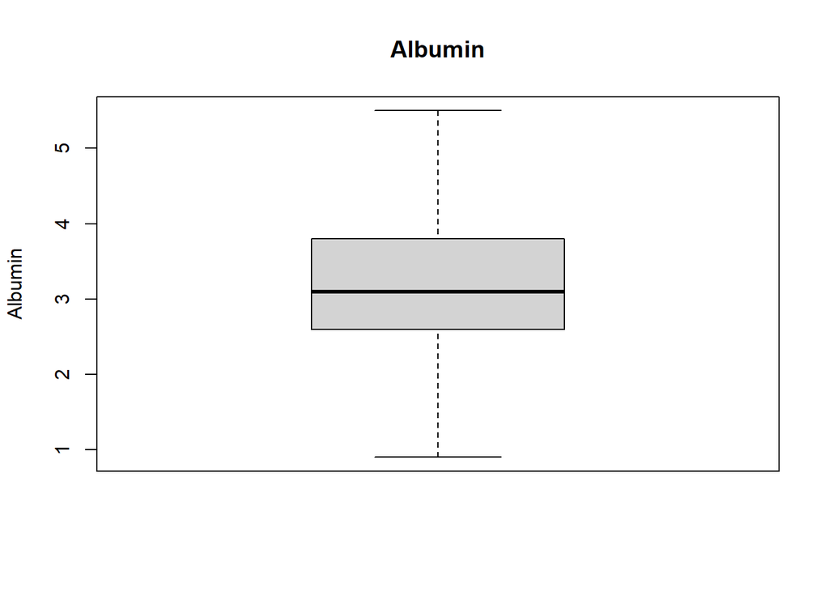

```r
boxplot(dataset$Albumin, main = "Albumin", ylab="Albumin")
```

the boxplot shows no outliers and the min value is 0.9 the max is 5.5 (range between 0.9 - 5.5) and the median is 3.1 the 3rd Qu is 3.8 the 1st Qu is 2.6 we can see from the values that the range is quite small compared to other attributes that we went through we will have to deal with that later.

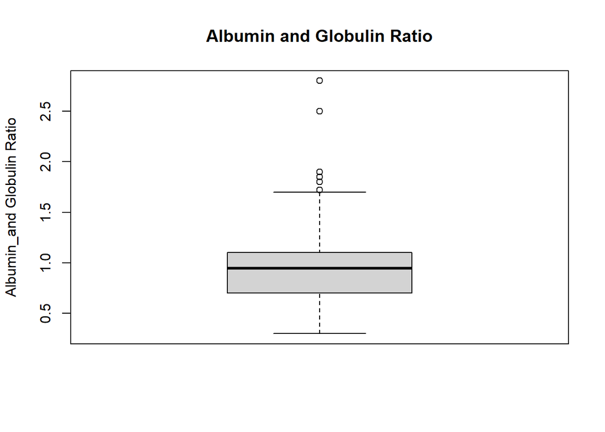

```r
boxplot(dataset$Albumin_and_Globulin_Ratio, main = "Albumin and Globulin Ratio", ylab = "Albumin_and Globulin Ratio")
```

the boxplot is showing the min value to be 0.3 and the max to be 2.8 (range between 0.3 - 2.8), the median to be 0.93 and 3rd Qu of 1.1 and 1st Qu of 0.7, the outliers are shown to start after approximately 1.7 but even the highest outlier is close to the 3rd Qu which means these are not true outliers.

## Dealing with the Outliers

Although the box plots show some extreme outliers we will not be removing them. mainly because most of them are not true outliers. also, According to a doctor those values are possible in liver disease patients, and each patient tests can vary greatly so we decided its best to keep those values as it will help the classification procedure.

# Data preprocessing

## encoding cateogrial value (gender)

convert the gender value to numeric to make classification easier, this step will result in making the male = to 0 and female = to 1.

```r
dataset$Gender[dataset$Gender == "Male"] <- 0
dataset$Gender[dataset$Gender == "Female"] <- 1
dataset$Gender=as.numeric(dataset$Gender)
head(dataset)
```

```
##   Age Gender Total_Bilirubin Direct_Bilirubin Alkaline_Phosphotase
## 1  65      1             0.7              0.1                  187
## 2  62      0            10.9              5.5                  699
## 3  62      0             7.3              4.1                  490
## 4  58      0             1.0              0.4                  182
## 5  72      0             3.9              2.0                  195
## 6  46      0             1.8              0.7                  208
##   Alamine_Aminotransferase Aspartate_Aminotransferase Total_Protiens Albumin
## 1                       16                         18            6.8     3.3
## 2                       64                        100            7.5     3.2
## 3                       60                         68            7.0     3.3
## 4                       14                         20            6.8     3.4
## 5                       27                         59            7.3     2.4
## 6                       19                         14            7.6     4.4
##   Albumin_and_Globulin_Ratio Dataset
## 1                       0.90       1
## 2                       0.74       1
## 3                       0.89       1
## 4                       1.00       1
## 5                       0.40       1
## 6                       1.30       1
```

## normalize all numeric attributes

```r
normalize <- function(x) {return ((x - min(x)) / (max(x) - min(x)))}
dataset$Total_Bilirubin = normalize(dataset$Total_Bilirubin)
dataset$Direct_Bilirubin = normalize(dataset$Direct_Bilirubin)
dataset$Alkaline_Phosphotase = normalize(dataset$Alkaline_Phosphotase)
dataset$Alamine_Aminotransferase = normalize(dataset$Alamine_Aminotransferase)
dataset$Aspartate_Aminotransferase = normalize(dataset$Aspartate_Aminotransferase)
dataset$Total_Protiens = normalize(dataset$Total_Protiens)
dataset$Albumin = normalize(dataset$Albumin)
dataset$Albumin_and_Globulin_Ratio = normalize(dataset$Albumin_and_Globulin_Ratio)
head(dataset)
```

```
##   Age Gender Total_Bilirubin Direct_Bilirubin Alkaline_Phosphotase
## 1  65      1     0.004021448       0.00000000           0.06057645
## 2  62      0     0.140750670       0.27551020           0.31069858
## 3  62      0     0.092493298       0.20408163           0.20859795
## 4  58      0     0.008042895       0.01530612           0.05813385
## 5  72      0     0.046916890       0.09693878           0.06448461
## 6  46      0     0.018766756       0.03061224           0.07083537
##   Alamine_Aminotransferase Aspartate_Aminotransferase Total_Protiens   Albumin
## 1              0.003015075               0.0016263468      0.5942029 0.5217391
## 2              0.027135678               0.0182964017      0.6956522 0.5000000
## 3              0.025125628               0.0117910144      0.6231884 0.5217391
## 4              0.002010050               0.0020329335      0.5942029 0.5434783
## 5              0.008542714               0.0099613743      0.6666667 0.3260870
## 6              0.004522613               0.0008131734      0.7101449 0.7608696
##   Albumin_and_Globulin_Ratio Dataset
## 1                      0.240       1
## 2                      0.176       1
## 3                      0.236       1
## 4                      0.280       1
## 5                      0.040       1
## 6                      0.400       1
```

## check correlation

```r
cor(dataset$Age,dataset$Dataset)
```

```
## [1] -0.1373506
```

```r
cor(dataset$Aspartate_Aminotransferase,dataset$Dataset)
```

```
## [1] -0.1519337
```

```r
cor(dataset$Alkaline_Phosphotase,dataset$Dataset)
```

```
## [1] -0.1848656
```

```r
cor(dataset$Alamine_Aminotransferase,dataset$Dataset)
```

```
## [1] -0.1634162
```

```r
cor(dataset$Direct_Bilirubin,dataset$Dataset)
```

```
## [1] -0.2460463
```

```r
cor(dataset$Total_Bilirubin,dataset$Dataset)
```

```
## [1] -0.2202076
```

```r
cor(dataset$Total_Protiens,dataset$Dataset)
```

```
## [1] 0.03500824
```

```r
cor(dataset$Albumin,dataset$Dataset)
```

```
## [1] 0.1613878
```

```r
cor(dataset$Albumin_and_Globulin_Ratio,dataset$Dataset)
```

```
## [1] 0.1623191
```

```r
chisq.test(dataset$Gender, dataset$Dataset)
```

```
##
##  Pearson's Chi-squared test with Yates' continuity correction
##
## data:  dataset$Gender and dataset$Dataset
## X-squared = 3.5466, df = 1, p-value = 0.05967
```

## show dataset after preprocessing

```r
head(dataset)
```

```
##   Age Gender Total_Bilirubin Direct_Bilirubin Alkaline_Phosphotase
## 1  65      1     0.004021448       0.00000000           0.06057645
## 2  62      0     0.140750670       0.27551020           0.31069858
## 3  62      0     0.092493298       0.20408163           0.20859795
## 4  58      0     0.008042895       0.01530612           0.05813385
## 5  72      0     0.046916890       0.09693878           0.06448461
## 6  46      0     0.018766756       0.03061224           0.07083537
##   Alamine_Aminotransferase Aspartate_Aminotransferase Total_Protiens   Albumin
## 1              0.003015075               0.0016263468      0.5942029 0.5217391
## 2              0.027135678               0.0182964017      0.6956522 0.5000000
## 3              0.025125628               0.0117910144      0.6231884 0.5217391
## 4              0.002010050               0.0020329335      0.5942029 0.5434783
## 5              0.008542714               0.0099613743      0.6666667 0.3260870
## 6              0.004522613               0.0008131734      0.7101449 0.7608696
##   Albumin_and_Globulin_Ratio Dataset
## 1                      0.240       1
## 2                      0.176       1
## 3                      0.236       1
## 4                      0.280       1
## 5                      0.040       1
## 6                      0.400       1
```

# Create a scatterplot for Alamine_Aminotransferase and Aspartate_Aminotransferase

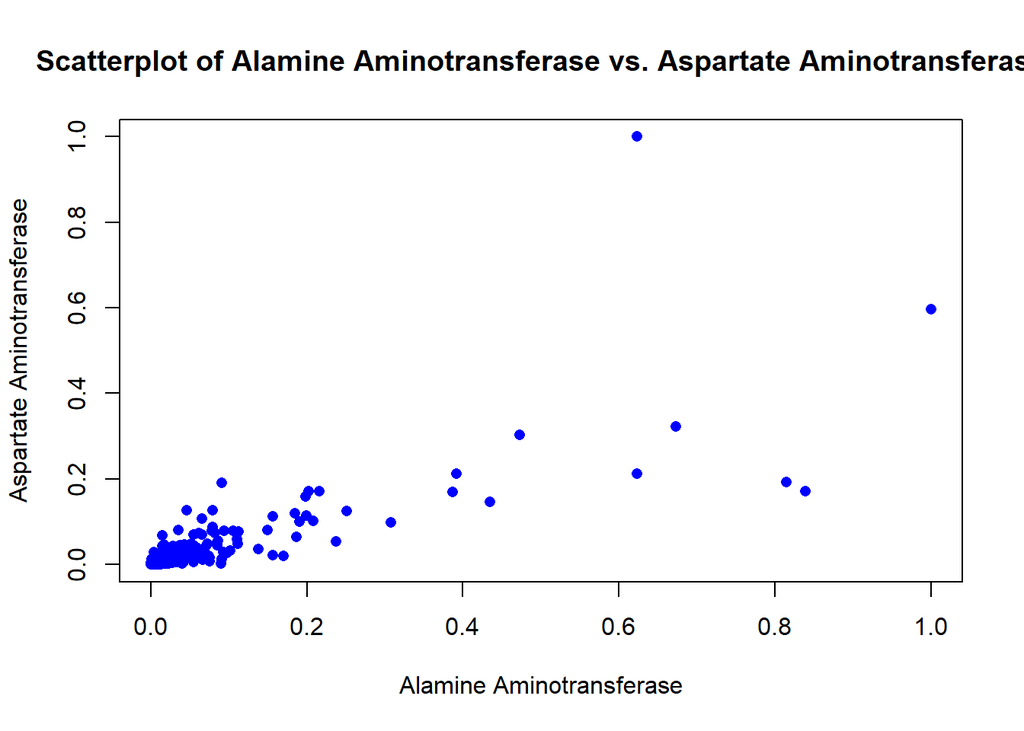

```r
 plot(dataset$Alamine_Aminotransferase,
     dataset$Aspartate_Aminotransferase,
     xlab = "Alamine Aminotransferase",
     ylab = "Aspartate Aminotransferase",
     main = "Scatterplot of Alamine Aminotransferase vs. Aspartate Aminotransferase",
     pch = 16, col = "blue")
```

# Create a bar plot

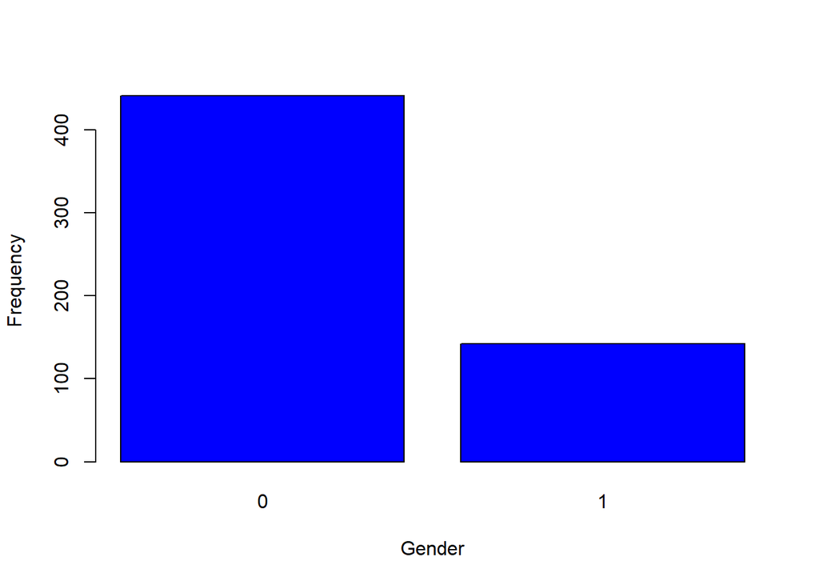

```r
barplot(table(dataset$Gender),
        ylab = "Frequency",
        xlab = "Gender",
        col =" blue")
```

we can see from the plot that female patients are less than half the number of male patients which means that the dataset is unbalanced.

# carete a scatter plot for Age and class label (dataset)

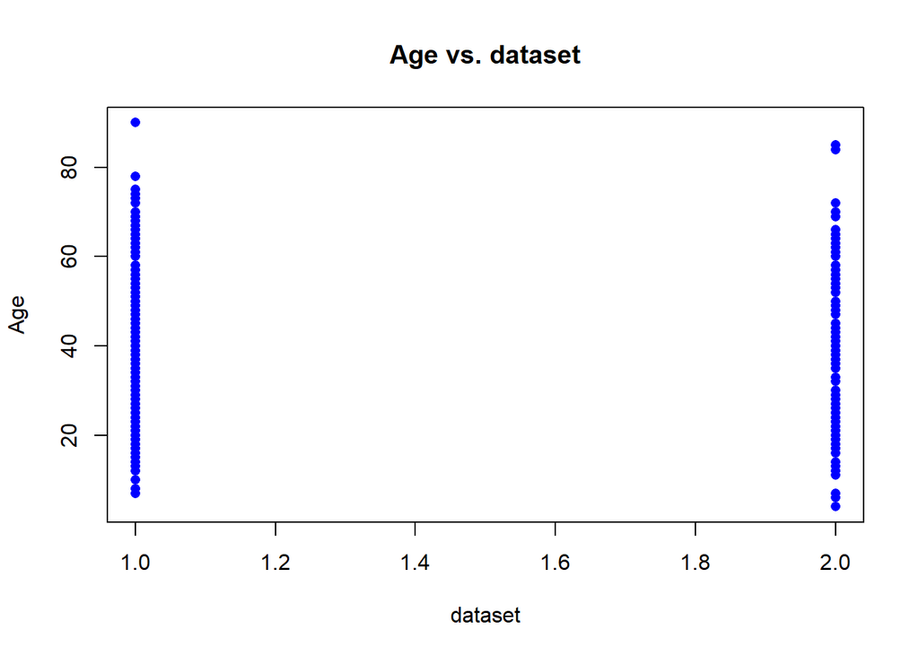

```r
plot(dataset$Dataset,
     dataset$Age,
     xlab = "dataset",
     ylab = "Age",
     main = "Age vs. dataset",
     pch = 16, col = "blue")
```

# carete a scatter plot for Total_Bilirubin and class label (dataset)

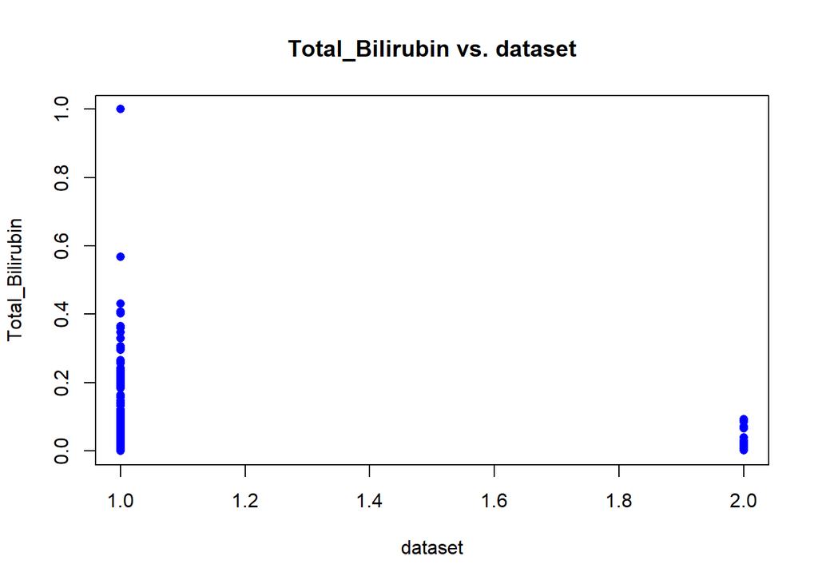

```r
plot(dataset$Dataset,
     dataset$Total_Bilirubin,
     xlab = "dataset",
     ylab = "Total_Bilirubin",
     main = "Total_Bilirubin vs. dataset",
     pch = 16, col = "blue")
```

from the graph it seems the higher the Total_Bilirubin the more liklely the patient is diagnosed with liver disease(1).

# carete a scatter plot for Direct_Bilirubin and class label (dataset)

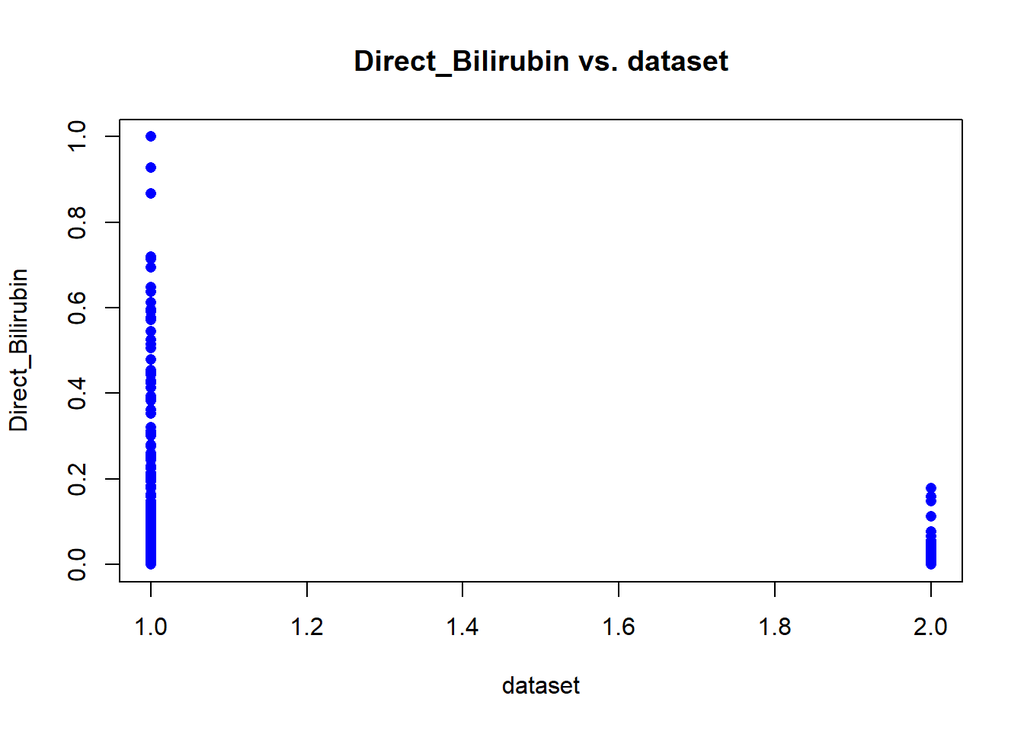

```r
plot(dataset$Dataset,
     dataset$Direct_Bilirubin,
     xlab = "dataset",
     ylab = "Direct_Bilirubin",
     main = "Direct_Bilirubin vs. dataset",
     pch = 16, col = "blue")
```

Again, from the graph it seems the higher the Direct_Bilirubin the more liklely the patient is diagnosed with liver disease(1).

# carete a scatter plot for Alkaline_Phosphotase and class label (dataset)

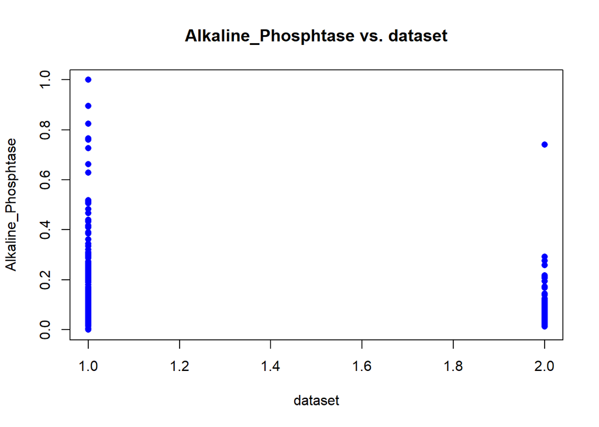

```r
plot(dataset$Dataset,
     dataset$Alkaline_Phosphotase,
     xlab = "dataset",
     ylab = "Alkaline_Phosphtase",
     main = "Alkaline_Phosphtase vs. dataset",
     pch = 16, col = "blue")
```

the plot shows that the patients diagnosed with liver disease(1) experience high levels of Alkaline_Phosphotase, it also show one point where the patient is not diagnosed with liver disease(2) but experience a relatively high level of Alkaline_Phosphotase.

# carete a scatter plot for Alamine_Aminotransferase and class label (dataset)

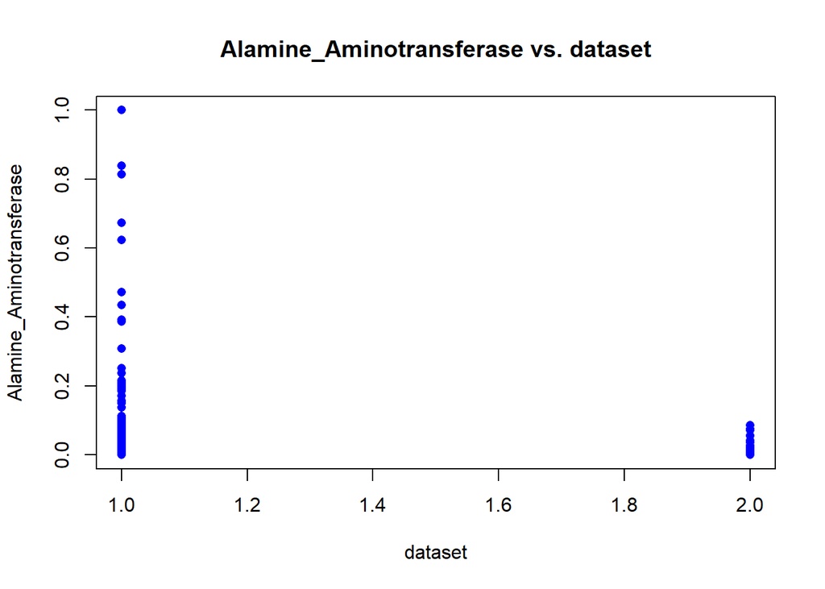

```r
plot(dataset$Dataset,
     dataset$Alamine_Aminotransferase,
     xlab = "dataset",
     ylab = "Alamine_Aminotransferase",
     main = "Alamine_Aminotransferase vs. dataset",
     pch = 16, col = "blue")
```

in this plot we can see that patients not diagnosed with liver disease(2) have low levels of Alamine_Aminotransferase its range is between 0 ans 0.1, while patients diagnosed with liver disease have rally high levels of Alamine_Aminotransferase.

# carete a scatter plot for Aspartate_Aminotransferase and class label (dataset)

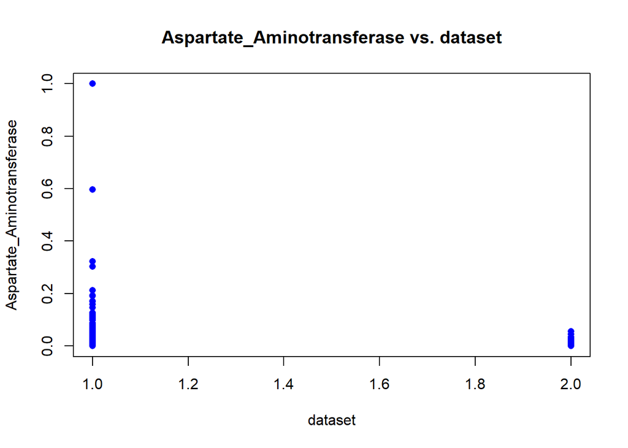

```r
plot(dataset$Dataset,
     dataset$Aspartate_Aminotransferase,
     xlab = "dataset",
     ylab = "Aspartate_Aminotransferase",
     main = "Aspartate_Aminotransferase vs. dataset",
     pch = 16, col = "blue")
```

as we can see from the plot, most paitents diagnosed with liver disease(1) have levels lower than 0.4 and few of them have values greater than 0.4, this could indicate the more of this enzyme means there might problems with the liver. patients not diagnosed with liver disease(2) have levels less than 0.1 .

# carete a scatter plot for Total_Protiens and class label (dataset)

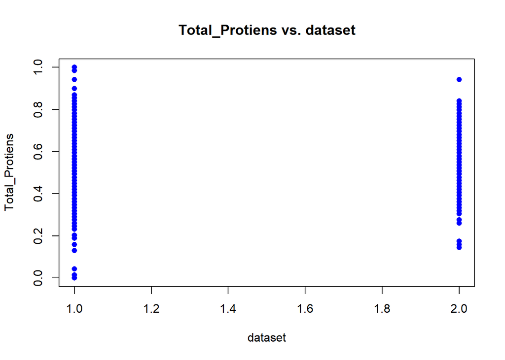

```r
plot(dataset$Dataset,
     dataset$Total_Protiens,
     xlab = "dataset",
     ylab = "Total_Protiens",
     main = "Total_Protiens vs. dataset",
     pch = 16, col = "blue")
```